# MATH 324 Final Project

Nathan Howland, Madilyn Webb, Ellise Putnam, Addison Hart

# 1. Project Description

This experiment is using a data set of the weather patterns across various cities in Australia, which contains variables such as the humidity, pressure, cloud coverage, temperature, and much more. This experiment was conducted as an observational study, where the goal of the study was to predict the possibility of rain based on these variables. We wanted to determine: 1) Whether additional weather variables led to a sufficiently improved model for predicting rainfall in Australia 2) Whether there are different variables that conclude better predictions based on the city within Australia

## 1.1 Research Questions

**Research Question 1:** What model should we use to predict rainfall across Australia? We want to discover which variables are the most reliable predictors of the rainfall for the “Next day”.

**Research Question 2:** Should we use different models for different locations? Are there models that are better suited for different locations across Australia, and what variables are the best for these locations?

## 1.2 Variables

| Variable | Type | E/R |
| --- | --- | --- |
| Location | Categorical | E |
| MinTemp | Quantitative | E |
| MaxTemp | Quantitative | E |
| Rainfall | Quantitative | E |
| Evaporation | Quantitative | E |
| Sunshine | Quantitative | E |
| WindGustDir | Categorical | E |
| WindGustSpeed | Quantitative | E |
| WindDir9am | Categorical | E |
| WindDir3pm | Categorical | E |
| WindSpeed9am | Quantitative | E |
| WindSpeed3pm | Quantitative | E |
| Humidity9am | Quantitative | E |
| Humidity3pm | Quantitative | E |
| Pressure9am | Quantitative | E |
| Pressure3pm | Quantitative | E |
| Cloud9am | Categorical | E |
| Cloud3pm | Categorical | E |
| Temp9am | Quantitative | E |
| Temp3pm | Quantitative | E |
| RainToday | Boolean | E |
| RainTomorrow | Boolean | R |

# 2. Detailed Exploratory Data Analysis (EDA)

### Question 1: Simple logistic regression model using RainToday as a predictor

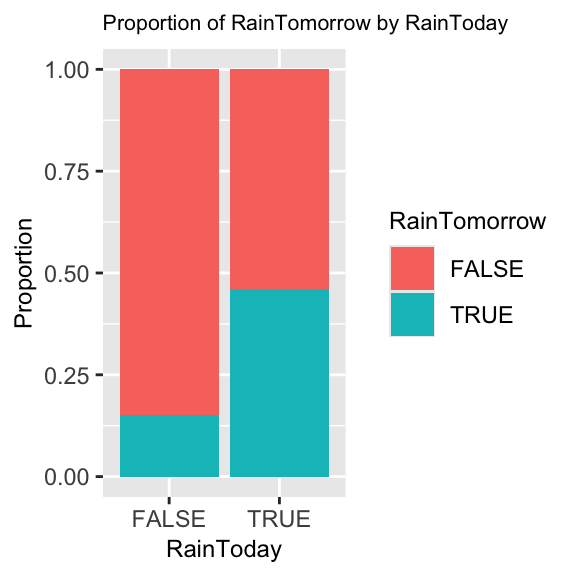

```r
# clean data
clean_weather <- weather %>% na.omit()

# model
lr_model <- glm(RainTomorrow ~ RainToday, family = binomial(link = "logit"), data = clean_weather)

ggplot(clean_weather, aes(x = RainToday, fill = RainTomorrow)) +
  geom_bar(position = "fill") +
  ylab("Proportion") +
  ggtitle("Proportion of RainTomorrow by RainToday") +
  theme(plot.title = element_text(size=8), axis.title = element_text(size = 9), legend.title = element_text(size = 9))
```

```r
mosaic(~ RainToday + RainTomorrow, data = clean_weather, shade = TRUE, legend = TRUE)
```

[output not shown]

### Question 2: Best model (using BIC) of all locations

```r
# clean data
clean_weather2 <- clean_weather
clean_weather2$Location <- factor(clean_weather2$Location)

# adding indicators
clean_weather2$IndLoc <- ifelse(clean_weather2$Location == "Sydney", 1, 0)
clean_weather2$IndWindGustDir <- ifelse(clean_weather2$WindGustDir == "W", 1, 0)
clean_weather2$IndWindDir9am <- ifelse(clean_weather2$WindDir9am == "W", 1, 0)
clean_weather2$IndWindDir3pm <- ifelse(clean_weather2$WindDir3pm == "WNW", 1, 0)

# performing stepwise and creating BIC
none <- lm(RainTomorrow ~ 1, data = clean_weather2)
full_model <- lm(RainTomorrow ~ ., data = clean_weather2)

# step(none, scope = list(upper = full_model), direction = "forward", really.big = T)
```

```r
all <- regsubsets(RainTomorrow ~ . - Location - WindGustDir - WindDir9am - WindDir3pm, data = clean_weather2, nbest = 1, really.big = TRUE)
plot(all, scale = "bic")
```

[output not shown]

As demonstrated from the following model, all variables prove to be significant predictors of RainTomorrow as all p-values are less than our significance level of 0.05. Additionally, we have an AIC value of 38,540 which is the lowest value we could attain for predicting RainTomorrow. For some context, when all other predictors are zero, the log odds of RainTomorrow is 74.50. Additionally, for each unit increase in sunshine, the log odds of RainTomorrow decrease by 0.168. This interpretation of variables also apply meaning that, for example, if it rained today (RainTodayTRUE), the log odds of RainTomorrow increase by 0.389 compared to when it didn’t rain today.

$$\hat{\text{RainTomorrow}} = 74.4980470 +
-0.1679587 * \text{Sunshine} + 0.0508944 * \text{WindGustSpeed} -
0.0330498 *$$
$$\text{WindSpeed3pm} +
0.0533006 * \text{Humidity3pm} - 0.0781103 * \text{Pressure3pm} +
0.3888131 * \text{RainTodayTRUE}$$

```r
# plot model
emplogitplot1(RainTomorrow ~ Sunshine + WindGustSpeed + WindSpeed3pm + Humidity3pm + Pressure3pm + RainToday, data = clean_weather2, ngroups = "all")

predicted <- predict(myModel, newdata = clean_weather2, type = "response")
```

[output not shown]

### Question 3: Simple Logistic regression model dependent on the location

```r
cleanWeather3 <- weather %>% na.omit()
SydneyWeather <- cleanWeather3 %>% filter(Location == "Sydney")
MelbourneWeather <- cleanWeather3 %>% filter(Location == "Melbourne")

gf_bar(~ RainToday | Location, data = SydneyWeather, fill = ~RainTomorrow, position = position_dodge())
gf_bar(~ RainToday | Location, data = MelbourneWeather, fill = ~RainTomorrow, position = position_dodge())

model_sydney <- glm(RainTomorrow ~ RainToday, family = binomial(link = "logit"), data = SydneyWeather)
model_melbourne <- glm(RainTomorrow ~ RainToday, family = binomial(link = "logit"), data = MelbourneWeather)
# summary(model_sydney)
# summary(model_melbourne)

# emplogitplot1(as.numeric(RainTomorrow) ~ as.numeric(RainToday), data = SydneyWeather, ngroups = "all")
# emplogitplot1(as.numeric(RainTomorrow) ~ as.numeric(RainToday), data = MelbourneWeather, ngroups = "all")
```

[output not shown]

### Question 4: Best model (using BIC) of two locations

```r
# Data cleaning
weather_cleaned_sydney <- weather %>%
  dplyr::select(-c(WindGustDir, WindDir9am, WindDir3pm)) %>%
  na.omit() %>%
  filter(Location == "Sydney") %>%
  dplyr::select(-c(Location))
weather_cleaned_melbourne <- weather %>%
  dplyr::select(-c(WindGustDir, WindDir9am, WindDir3pm)) %>%
  na.omit() %>%
  filter(Location == "Melbourne") %>%
  dplyr::select(-c(Location))

# BIC plot Sydney
all_sydney <- regsubsets(RainTomorrow ~ ., data = weather_cleaned_sydney, method = "exhaustive")
plot(all_sydney, scale = "bic")
# summaryHH(all_sydney)
rain_tomorrow_sydney_model <- glm(RainTomorrow ~ MinTemp + MaxTemp + Sunshine + WindGustSpeed + Humidity3pm + RainToday, data = weather_cleaned_sydney)
```

[output not shown]

```r
# Linearity odds plot Sydney
emplogitplot1(RainTomorrow ~ Sunshine + MinTemp + MaxTemp + WindGustSpeed + Humidity3pm + RainToday, data = weather_cleaned_sydney, ngroups = "all")
```

[output not shown]

```r
# cor(weather_cleaned_sydney)

# BIC plot Melbourne
all_melbourne <- regsubsets(RainTomorrow ~ ., data = weather_cleaned_melbourne, method = "exhaustive")
plot(all_melbourne, scale = "bic")
# summaryHH(all_melbourne)
rain_tomorrow_melbourne_model <- glm(RainTomorrow ~ MinTemp + MaxTemp + Sunshine + WindGustSpeed + Humidity3pm + RainToday, data = weather_cleaned_melbourne)
```

[output not shown]

```r
# Linearity odds plot Melbourne
emplogitplot1(RainTomorrow ~ Sunshine + MinTemp + MaxTemp + WindGustSpeed + Humidity3pm + RainToday, data = weather_cleaned_melbourne, ngroups = "all")

# cor(weather_cleaned_melbourne)
```

[output not shown]

# 3. Statistical Analysis

## Simple logistic regression model using RainToday as a predictor

## Simple Logistic regression model dependent on the location

The model assumptions we need to satisfy for these two models are:

- Linearity: We cannot prove this assumption because a model using only one categorical boolean variable is not a line. This model essentially uses the number of datapoints having rain yesterday in order to determine a value for rain today.
- Independence: The datapoints were obtained from a sensor whose results are not dependent on yesterday’s results, so they are independent.
- Randomness: The datapoints are always recorded from a sensor located in the same geographical location. For example, datapoints from the Sydney Airport are always recorded near the airport. That means that there is no randomness of recordings in the general area indicated by the datapoint. We cannot, therefore, generalize to the entire city.

## Best model (using BIC) of all locations

## Best model (using BIC) of two locations and the best model (using BIC) of all locations

**Research Question 1**

### Question 1: Simple logistic regression model using RainToday as a predictor

After the statistical analysis of this simple logistic regression model, we found that it is fairly sufficient at predicting RainTomorrow. This model obtained a Brier score of 0.165, which is a relatively low score, which shows that the model is making fairly accurate predictions of rain tomorrow. The odds ratio of 4.84 indicates that the odds of rain tomorrow are 4.84 times higher when it rained today compared to when it didn’t rain today.

### Question 2: Best model (using BIC) of all locations

Given our brier score of 0.1066608 which indicates that, on average, the squared difference between the predicted probabilities of rain tomorrow and the actual outcomes is 0.1066608. Overall, our score of 0.1066608 indicates that our model is making accurate predictions of rain tomorrow, which displays a greater accuracy than the simple logistic regression model from question 1.

**Research Question 2**

### Question 3: Simple Logistic regression model dependent on the location

In the basic forecast model where we solely used RainToday to predict RainTomorrow, we calculated the brier score and odds ratio for both Sydney and Melbourne. The brier scores for both Sydney and Melbourne are very similar with values of 0.165 and 0.179 respectively. Once we create a model with more explanatory variables such as Sunshine, MinTemp, MaxTemp, WindGustSpeed, Humidity3pm, and RainToday, we get much lower Brier Scores for both Sydney and Melbourne with values of 0.118 and 0.137, which indicates that this model has greater accuracy in predicting RainTomorrow.

### Question 4: Best model (using BIC) of two locations

# 4. Conclusions

**Research Question 1:** Based on the results of our analysis, and a Brier score of 0.107, we can conclude that the best model for predicting rainfall across Australia is the model that includes the variables Sunshine, WindGustSpeed, WindSpeed3pm, Humidity3pm, Pressure3pm, and RainToday. However, we can also conclude that the simple logistic regression model using RainToday as a predictor is also a reliable model for predicting rainfall across Australia, especially when without access to the extra variables used in the best model.

# 5. Appendix

Question 1 Code __________________________________________________________________________________________________________________________________________________

```r
# clean data
clean_weather <- weather %>% na.omit()

# model
lr_model <- glm(RainTomorrow ~ RainToday, family = binomial(link = "logit"), data = clean_weather)

# eda
ggplot(clean_weather, aes(x = RainToday, fill = RainTomorrow)) +
  geom_bar(position = "fill") +
  ylab("Proportion") +
  ggtitle("Proportion of Rain Tomorrow by Rain Today")

mosaic(~ RainToday + RainTomorrow, data = clean_weather, shade = TRUE, legend = TRUE)

emplogitplot1(as.numeric(RainTomorrow) ~ as.numeric(RainToday), data = clean_weather, ngroups = "all")

# Brier Score
prediction <- predict(lr_model, clean_weather, type = "response")
BriarScore <- mean((prediction - clean_weather$RainTomorrow)^2)

# Odds Ratio
pi_rainToday <- exp(-1.720027 + 1.576018) / (1 + exp(-1.720027 + 1.576018))
odds_rainToday <- pi_rainToday / (1 - pi_rainToday)
pi_not_rainToday <- exp(-1.720027) / (1 + exp(-1.720027))
odds_not_rainToday <- pi_not_rainToday / (1 - pi_not_rainToday)
```

Question 2 Code __________________________________________________________________________________________________________________________________________________

```r
# clean data
clean_weather2 <- clean_weather
clean_weather2$Location <- factor(clean_weather2$Location)

# adding indicators
clean_weather$IndLoc <- ifelse(clean_weather$Location == "Sydney", 1, 0)
clean_weather$IndWindGustDir <- ifelse(clean_weather$WindGustDir == "W", 1, 0)
clean_weather$IndWindDir9am <- ifelse(clean_weather$WindDir9am == "W", 1, 0)
clean_weather$IndWindDir3pm <- ifelse(clean_weather$WindDir3pm == "WNW", 1, 0)

# performing stepwise and creating BIC
none <- lm(RainTomorrow ~ 1, data = clean_weather)
full_model <- lm(RainTomorrow ~ ., data = clean_weather)

step(none, scope = list(upper = full_model), direction = "forward", really.big = T)

all <- regsubsets(RainTomorrow ~ . - Location - WindGustDir - WindDir9am - WindDir3pm, data = clean_weather, nbest = 1, really.big = TRUE)
plot(all, scale = "bic")

summaryHH(all)

# create model based on BIC
myModel <- glm(RainTomorrow ~ Sunshine + WindGustSpeed + WindSpeed3pm + Humidity3pm + Pressure3pm + RainToday, family = "binomial", data = clean_weather)
summary(myModel)

# plot model
emplogitplot1(RainTomorrow ~ Sunshine + WindGustSpeed + WindSpeed3pm + Humidity3pm + Pressure3pm + RainToday, data = clean_weather, ngroups = "all")

predicted <- predict(myModel, newdata = clean_weather, type = "response")


brier_score <- compute_brier(clean_weather$RainTomorrow, predicted)
brier_score
```

Question 3 Code __________________________________________________________________________________________________________________________________________________

```r
cleanWeather3 <- weather %>% na.omit()
SydneyWeather <- cleanWeather3 %>% filter(Location == "Sydney")
MelbourneWeather <- cleanWeather3 %>% filter(Location == "Melbourne")

gf_bar(~ RainToday | Location, data = SydneyWeather, fill = ~RainTomorrow, position = position_dodge())
gf_bar(~ RainToday | Location, data = MelbourneWeather, fill = ~RainTomorrow, position = position_dodge())

model_sydney <- glm(RainTomorrow ~ RainToday, family = binomial(link = "logit"), data = SydneyWeather)
model_melbourne <- glm(RainTomorrow ~ RainToday, family = binomial(link = "logit"), data = MelbourneWeather)
summary(model_sydney)
summary(model_melbourne)

plot(model_sydney, which = 1)
plot(model_melbourne, which = 1)
emplogitplot1(as.numeric(RainTomorrow) ~ as.numeric(RainToday), data = SydneyWeather, ngroups = "all")
emplogitplot1(as.numeric(RainTomorrow) ~ as.numeric(RainToday), data = MelbourneWeather, ngroups = "all")

# Make predictions for Sydney
predictions_sydney <- predict(model_sydney, newdata = SydneyWeather, type = "response")

# Make predictions for Melbourne
predictions_melbourne <- predict(model_melbourne, newdata = MelbourneWeather, type = "response")

# Compute Brier scores for Sydney
brier_score_sydney <- compute_brier(SydneyWeather$RainTomorrow, predictions_sydney)
brier_score_sydney

# Compute Brier scores for Melbourne
brier_score_melbourne <- compute_brier(MelbourneWeather$RainTomorrow, predictions_melbourne)
brier_score_melbourne

# Calculate odds ratios
pi_sydney <- exp(-1.58290 + 1.62910) / (1 + exp(-1.58290 + 1.62910))
odds_sydney <- pi_sydney / (1 - pi_sydney)
odds_sydney

pi_melbourne <- exp(-1.50550 + 1.02034) / (1 + exp(-1.50550 + 1.02034))
odds_melbourne <- pi_melbourne / (1 - pi_melbourne)
odds_melbourne
```

Question 4 Code __________________________________________________________________________________________________________________________________________________

```r
# Data cleaning
weather_cleaned_sydney <- weather %>%
  dplyr::select(-c(WindGustDir, WindDir9am, WindDir3pm)) %>%
  na.omit() %>%
  filter(Location == "Sydney") %>%
  dplyr::select(-c(Location))
weather_cleaned_melbourne <- weather %>%
  dplyr::select(-c(WindGustDir, WindDir9am, WindDir3pm)) %>%
  na.omit() %>%
  filter(Location == "Melbourne") %>%
  dplyr::select(-c(Location))

# BIC plot Sydney
all_sydney <- regsubsets(RainTomorrow ~ ., data = weather_cleaned_sydney, method = "exhaustive")
plot(all_sydney, scale = "bic")
summaryHH(all_sydney)
rain_tomorrow_sydney_model <- glm(RainTomorrow ~ MinTemp + MaxTemp + Sunshine + WindGustSpeed + Humidity3pm + RainToday, data = weather_cleaned_sydney)
# Linearity odds plot Sydney
emplogitplot1(RainTomorrow ~ Sunshine + MinTemp + MaxTemp + WindGustSpeed + Humidity3pm + RainToday, data = weather_cleaned_sydney, ngroups = "all")

# cor(weather_cleaned_sydney)

# BIC plot Melbourne
all_melbourne <- regsubsets(RainTomorrow ~ ., data = weather_cleaned_melbourne, method = "exhaustive")
plot(all_melbourne, scale = "bic")
summaryHH(all_melbourne)
rain_tomorrow_melbourne_model <- glm(RainTomorrow ~ MinTemp + MaxTemp + Sunshine + WindGustSpeed + Humidity3pm + RainToday, data = weather_cleaned_melbourne)

# Linearity odds plot Melbourne
emplogitplot1(RainTomorrow ~ Sunshine + MinTemp + MaxTemp + WindGustSpeed + Humidity3pm + RainToday, data = weather_cleaned_melbourne, ngroups = "all")

# cor(weather_cleaned_melbourne)

# Brier scores
print(paste("Brier score for Sydney:", compute_brier(weather_cleaned_sydney$RainTomorrow, predict(rain_tomorrow_sydney_model, weather_cleaned_sydney, type = "response"))))
print(paste("Brier score for Melbourne:", compute_brier(weather_cleaned_melbourne$RainTomorrow, predict(rain_tomorrow_melbourne_model, weather_cleaned_melbourne, type = "response"))))
```